# 回帰分析（交差項）模範解答・解説

Masahiko Asano

2020-07-14

# 5. 問題

「選挙費用が得票率に与える影響は、当選回数の多寡と関係があるのかどうか」を調べたい。

・分析に使うデータ：衆議院選挙データhr96_14.csv

・2012年に実施された総選挙データと次の三つの変数を使って分析しなさい。

**voteshare** : 得票率 (%)  
**exppv** : 有権者一人当たりに候補者が費やした選挙費用 (yen)  
**previous** :当選回数

Q1: 上記三つの変数に関する記述統計を表示させなさい。

Q2: 選挙費用と得票率の散布図を表示し、簡単にコメントしなさい。

Q3: 当選回数と得票率の散布図を表示し、簡単にコメントしなさい。

Q4: 衆議院選挙において「選挙費用が得票率に与える影響は、当選回数の多寡と関係があるのかどうか」に関するあなたの仮説を述べなさい。また、そう考える理由を簡単に述べなさい。

Q5: 「選挙費用が得票率に与える影響は、当選回数の多寡と関係がある」と言えるか？  
その根拠を示しなさい。

Q6: 当選回数が「少ない場合」と「多い場合」における選挙費用と得票率の関係を、一つの散布図に描きなさい。  
散布図に二つの回帰式も表示しなさい。

Q7: Delta method を使って当選回数を 6 つのレベルに分け、選挙費用が得票率に与える影響力を明示しなさい。

Q8: Q7 の結果をわかりやすいグラフで表示し、分析結果を述べなさい。

# 模範解答

## Q1:

上記三つの変数に関する記述統計を表示させなさい。

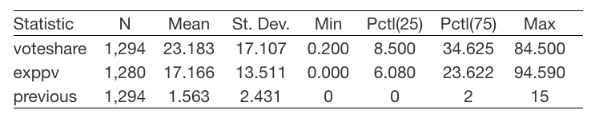

## Q2:

選挙費用と得票率の散布図を表示し、簡単にコメントしなさい。

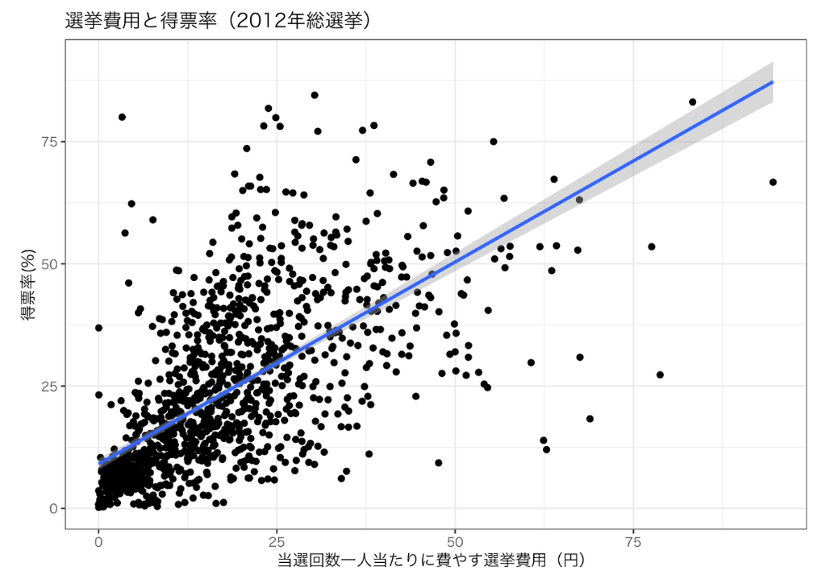

・選挙費用と得票率は正の相関。

## Q3:

当選回数と得票率の散布図を表示し、簡単にコメントしなさい。

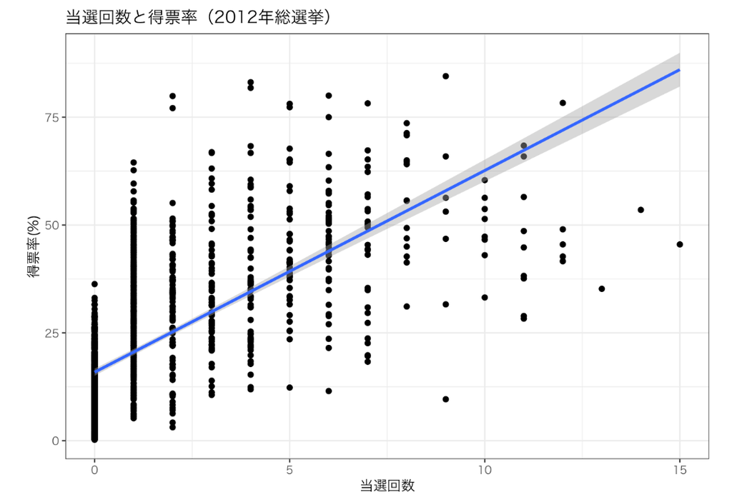

・当選回数と得票率の間に正の相関。

## Q4:

衆議院選挙において「選挙費用が得票率に与える影響は、当選回数の多寡と関係があるのかどうか」に関するあなたの仮説を述べなさい。また、そう考える理由を簡単に述べなさい。

仮説：当選回数が多い候補者ほど、選挙費用が得票率に与える影響が小さいはず  
理由：当選回数を重ねたベテラン候補者は知名度が高まるため、選挙費用を使わなくても得票できると思われるから  
他方、当選回数が少ない候補者は得票のためによりお金を使う必要があると思われる

## Q5:

「選挙費用が得票率に与える影響は、当選回数の多寡と関係がある」と言えるか？  
その根拠を示しなさい。

関係があるといえる。  
根拠：当選回数を重ねるほど候補者の個人後援会が充実し堅実な支持者も増える。従って、ベテラン候補者は、当選回数の少ない候補者ほど選挙費用を使わなくても得票できると思われる。

## Q6:

当選回数が「少ない場合」と「多い場合」における選挙費用と得票率の関係を、一つの散布図に描きなさい。散布図に二つの回帰式も表示しなさい。

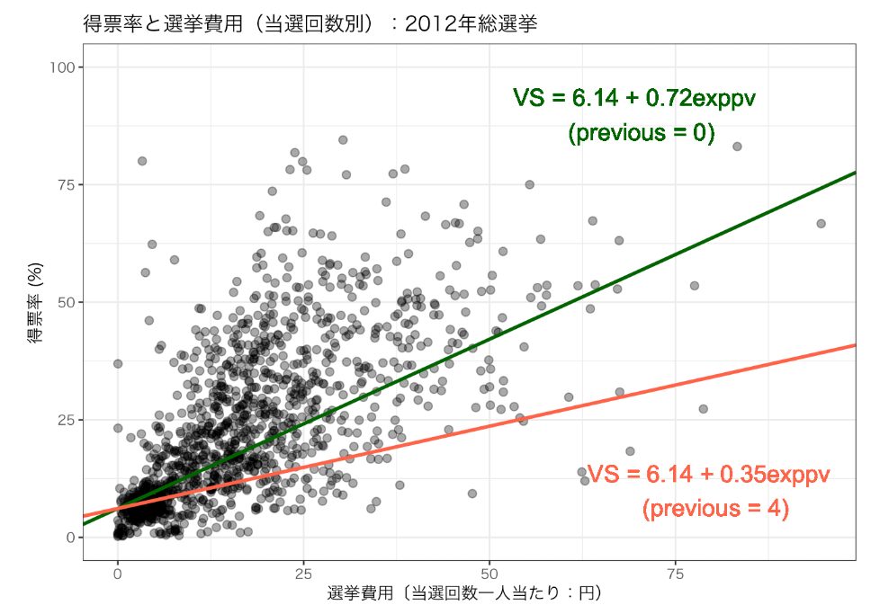

## Q7:

Delta method を使って当選回数を 6 つのレベルに分け、選挙費用が得票率に与える影響力を明示しなさい。

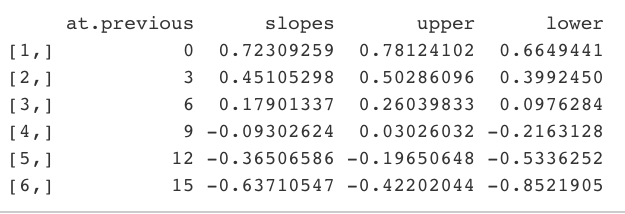

## Q8:

Q7 の結果をわかりやすいグラフで表示し、分析結果を述べなさい。

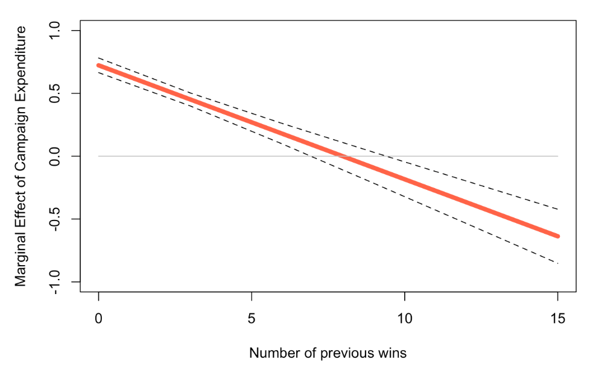

分析結果：  
(1) 当選回数が増えるにつれて、得票率に与える選挙費用の影響は小さくなっている  
(2) 統計的に有意なのは当選回数が0回から6回と10回以降だけ  
(3) 当選回数が 7回から9回の候補者は統計的に有意ではない

# 解説

分析に必要なRパッケージ

```r
library(tidyverse)
library(stargazer)
library(msm)
```

## 1. データの読み取りと前準備

```r
hr <- read.csv("data/hr96_14.csv", na = ".") # na = "."は欠損処理
```

・`ggplot` で文字バケしない設定 (For Mac Users)

```r
theme_set(theme_bw(base_size = 10,
                        base_family = "HiraginoSans-W3"))
```

・データフレーム hr の変数名を確認。

```r
names(hr)
```

```
 [1] "year"       "ku"         "kun"        "party"      "party_code"
 [6] "mag"        "name"       "age"        "status"     "nocand"
[11] "rank"       "wl"         "previous"   "vote"       "voteshare"
[16] "eligible"   "turnout"    "exp"        "exppv"      "ldp"
[21] "dpj"
```

・このデータの中から2012年の衆議院選挙データだけ取り出し、次の三つの変数 (`voteshare`, `exppv`, `previous`) を使って重回帰分析を行ってみる。

```r
hr2012 <- hr %>%
  filter(year == 2012) %>%　  　# 2012年のデータだけを選ぶ
  select(voteshare, exppv, previous) # 三つの変数だけを選ぶ
```

・`str()`関数を使って変数の `class` が `numeric` もしくは `integer` であることを確認。  
・もし `numeric` か `integer` 以外なら、`numeric` に変換する。

```r
str(hr2012)
```

```
'data.frame':   1294 obs. of  3 variables:
 $ voteshare: num  40.7 31.8 19.3 8.2 44.8 31.9 15.2 8.1 36.7 34.9 ...
 $ exppv    : num  40.76 10.35 31.75 3.27 19.81 ...
 $ previous : int  1 1 0 0 6 1 0 0 1 6 ...
```

→ 変更する必要はない  
参考：例） `voteshare` を `numeric` に変更する方法  
注：ここでは変更する必要はない

```r
hr2012$voteshare <- as.numeric(levels(hr2012$voteshare))[hr2012$voteshare]
```

## 2. 2012年の衆議院選挙データ記述統計

```r
library("stargazer")
```

```r
stargazer(hr2012, type = "html")
```

| Statistic | N | Mean | St. Dev. | Min | Pctl(25) | Pctl(75) | Max |
| --- | --- | --- | --- | --- | --- | --- | --- |
| voteshare | 1,294 | 23.183 | 17.107 | 0.200 | 8.500 | 34.625 | 84.500 |
| exppv | 1,280 | 17.166 | 13.511 | 0.000 | 6.080 | 23.622 | 94.590 |
| previous | 1,294 | 1.563 | 2.431 | 0 | 0 | 2 | 15 |

## 3. 散布図を描く

①選挙費用（説明変数）と得票率（応答変数）  
②当選回数（`moderator変数`）と得票率（応答変数）

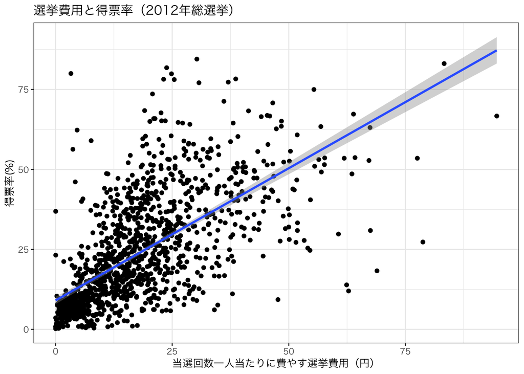

```r
ggplot(hr2012, aes(exppv, voteshare)) +
  geom_point() +
  labs(x = "当選回数一人当たりに費やす選挙費用（円）", y = "得票率(%)",
         title = "選挙費用と得票率（2012年総選挙）") +
  stat_smooth(method = lm)
```

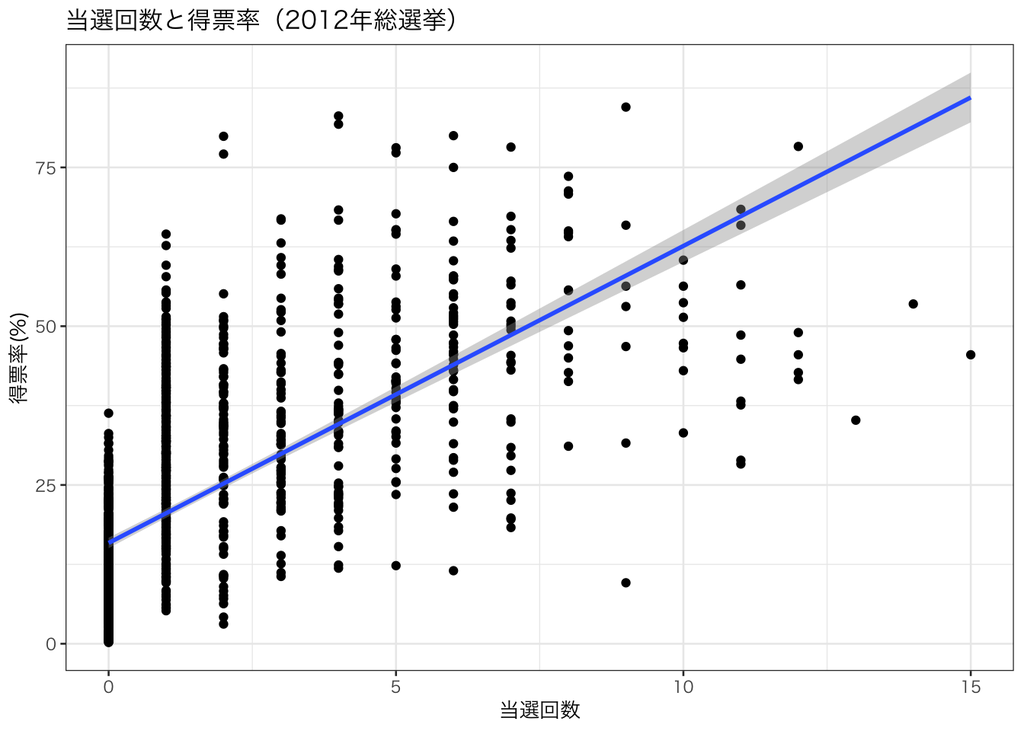

```r
ggplot(hr2012, aes(previous, voteshare)) +
  geom_point() +
  labs(x = "当選回数", y = "得票率(%)",
         title = "当選回数と得票率（2012年総選挙）") +
  stat_smooth(method = lm)
```

・選挙費用と得票率は正の相関。  
・当選回数と得票率の間に正の相関。  
・ **知りたいのは「選挙費用が得票率に与える影響は、当選回数の多寡と関係があるのかどうか」ということ**